# **SpaceX Falcon 9 first stage Landing Prediction**

**import libraries and functions**

```python
import requests
import pandas as pd
import numpy as np
import datetime
import matplotlib.pyplot as plt
import seaborn as sns

# Setting this option will print all collumns of a dataframe
pd.set_option('display.max_columns', None)
# Setting this option will print all of the data in a feature
pd.set_option('display.max_colwidth', None)
```

Below we will define a series of helper functions that will help us use the API to extract information using identification numbers in the launch data.

From the `rocket` column we would like to learn the booster name.

```python
# Takes the dataset and uses the rocket column to call the API and append the data to the list
def getBoosterVersion(data):
    for x in data['rocket']:
       if x:
        response = requests.get("https://api.spacexdata.com/v4/rockets/"+str(x)).json()
        BoosterVersion.append(response['name'])
```

From the `launchpad` we would like to know the name of the launch site being used, the logitude, and the latitude.

```python
# Takes the dataset and uses the launchpad column to call the API and append the data to the list
def getLaunchSite(data):
    for x in data['launchpad']:
       if x:
         response = requests.get("https://api.spacexdata.com/v4/launchpads/"+str(x)).json()
         Longitude.append(response['longitude'])
         Latitude.append(response['latitude'])
         LaunchSite.append(response['name'])
```

From the `payload` we would like to learn the mass of the payload and the orbit that it is going to.

```python
# Takes the dataset and uses the payloads column to call the API and append the data to the lists
def getPayloadData(data):
    for load in data['payloads']:
       if load:
        response = requests.get("https://api.spacexdata.com/v4/payloads/"+load).json()
        PayloadMass.append(response['mass_kg'])
        Orbit.append(response['orbit'])
```

From `cores` we would like to learn the outcome of the landing, the type of the landing, number of flights with that core, whether gridfins were used, wheter the core is reused, wheter legs were used, the landing pad used, the block of the core which is a number used to seperate version of cores, the number of times this specific core has been reused, and the serial of the core.

```python
# Takes the dataset and uses the cores column to call the API and append the data to the lists
def getCoreData(data):
    for core in data['cores']:
            if core['core'] != None:
                response = requests.get("https://api.spacexdata.com/v4/cores/"+core['core']).json()
                Block.append(response['block'])
                ReusedCount.append(response['reuse_count'])
                Serial.append(response['serial'])
            else:
                Block.append(None)
                ReusedCount.append(None)
                Serial.append(None)
            Outcome.append(str(core['landing_success'])+' '+str(core['landing_type']))
            Flights.append(core['flight'])
            GridFins.append(core['gridfins'])
            Reused.append(core['reused'])
            Legs.append(core['legs'])
            LandingPad.append(core['landpad'])
```

Now let's start requesting rocket launch data from SpaceX API with the following URL:

```python
spacex_url="https://api.spacexdata.com/v4/launches/past"
response = requests.get(spacex_url)
```

```python
response.status_code
```

```
200
```

Now we decode the response content as a Json using `.json()` and turn it into a Pandas dataframe using `.json_normalize()`

```python
# Use json_normalize method to convert the json result into a dataframe
data = response.json()

df = pd.json_normalize(data)
```

```python
#df.head()
```

```python
df.columns
```

```
Index(['static_fire_date_utc', 'static_fire_date_unix', 'net', 'window',
       'rocket', 'success', 'failures', 'details', 'crew', 'ships', 'capsules',
       'payloads', 'launchpad', 'flight_number', 'name', 'date_utc',
       'date_unix', 'date_local', 'date_precision', 'upcoming', 'cores',
       'auto_update', 'tbd', 'launch_library_id', 'id', 'fairings.reused',
       'fairings.recovery_attempt', 'fairings.recovered', 'fairings.ships',
       'links.patch.small', 'links.patch.large', 'links.reddit.campaign',
       'links.reddit.launch', 'links.reddit.media', 'links.reddit.recovery',
       'links.flickr.small', 'links.flickr.original', 'links.presskit',
       'links.webcast', 'links.youtube_id', 'links.article', 'links.wikipedia',
       'fairings'],
      dtype='object')
```

Lot of the data are IDs. For example the rocket column has no information about the rocket just an identification number.

We will now use the API again to get information about the launches using the IDs given for each launch. Specifically we will be using columns `rocket`, `payloads`, `launchpad`, and `cores`.

```python
# We will remove rows with multiple cores because those are falcon rockets with 2 extra rocket boosters and rows that have multiple payloads in a single rocket.
df = df[df['cores'].map(len)==1]
df = df[df['payloads'].map(len)==1]

# Since payloads and cores are lists of size 1 we will also extract the single value in the list and replace the feature.
df['cores'] = df['cores'].map(lambda x : x[0])
df['payloads'] = df['payloads'].map(lambda x : x[0])

# We also want to convert the date_utc to a datetime datatype and then extracting the date leaving the time
df['date'] = pd.to_datetime(df['date_utc']).dt.date

# Using the date we will restrict the dates of the launches
df = df[df['date'] <= datetime.date(2020, 11, 13)]   # select the rows which has the launching date less than or equal to 2020/11/13
```

- From the `rocket` we would like to learn the booster name
- From the `payload` we would like to learn the mass of the payload and the orbit that it is going to
- From the `launchpad` we would like to know the name of the launch site being used, the longitude, and the latitude.
- **From `cores` we would like to learn the outcome of the landing, the type of the landing, number of flights with that core, whether gridfins were used, whether the core is reused, whether legs were used, the landing pad used, the block of the core which is a number used to seperate version of cores, the number of times this specific core has been reused, and the serial of the core.**

The data from these requests will be stored in lists and will be used to create a new dataframe.

```python
#Global variables
BoosterVersion = []
PayloadMass = []
Orbit = []
LaunchSite = []
Outcome = []
Flights = []
GridFins = []
Reused = []
Legs = []
LandingPad = []
Block = []
ReusedCount = []
Serial = []
Longitude = []
Latitude = []

# Call getBoosterVersion
getBoosterVersion(df)
```

```python
BoosterVersion[0:3]
```

```
['Falcon 1', 'Falcon 1', 'Falcon 1']
```

```python
# Call getLaunchSite
getLaunchSite(df)
# Call getPayloadData
getPayloadData(df)
# Call getCoreData
getCoreData(df)
```

We construct the new dataset using the data we have obtained. We use only the important features dropping columns that contain links etc. We combine the columns into a dictionary.

```python
launch_dict = {'FlightNumber': list(df['flight_number']),
'Date': list(df['date']),
'BoosterVersion':BoosterVersion,
'PayloadMass':PayloadMass,
'Orbit':Orbit,
'LaunchSite':LaunchSite,
'Outcome':Outcome,
'Flights':Flights,
'GridFins':GridFins,
'Reused':Reused,
'Legs':Legs,
'LandingPad':LandingPad,
'Block':Block,
'ReusedCount':ReusedCount,
'Serial':Serial,
'Longitude': Longitude,
'Latitude': Latitude}
```

Then, we need to create a Pandas data frame from the dictionary launch_dict.

```python
df_new = pd.DataFrame(launch_dict)
```

```python
#df_new
```

### Filter the dataframe to only include `Falcon 9` launches

```python
data_falcon9 =  df_new.query('BoosterVersion != "Falcon 1"').copy()
```

```python
#data_falcon9.head()
```

### Rearranging the flight number

```python
data_falcon9.loc[:,'FlightNumber'] = list(range(1, data_falcon9.shape[0]+1))
#data_falcon9
```

```python
#data_falcon9.head()
```

### Data Wrangling

checking to see if there are missing values

```python
data_falcon9.isnull().sum()
```

```
FlightNumber       0
Date               0
BoosterVersion     0
PayloadMass        5
Orbit              0
LaunchSite         0
Outcome            0
Flights            0
GridFins           0
Reused             0
Legs               0
LandingPad        26
Block              0
ReusedCount        0
Serial             0
Longitude          0
Latitude           0
dtype: int64
```

### Replacing the nan values in the `PayloadMass` with mean values in the PayLoadMass column.

```python
# Calculate the mean value of PayloadMass column
payload_mean = data_falcon9['PayloadMass'].mean()

# Replace the np.nan values with its mean value
data_falcon9['PayloadMass'] = data_falcon9['PayloadMass'].replace(np.nan, payload_mean)
```

```python
data_falcon9.isnull().sum()
```

```
FlightNumber       0
Date               0
BoosterVersion     0
PayloadMass        0
Orbit              0
LaunchSite         0
Outcome            0
Flights            0
GridFins           0
Reused             0
Legs               0
LandingPad        26
Block              0
ReusedCount        0
Serial             0
Longitude          0
Latitude           0
dtype: int64
```

### calculate the number of launches on each site

```python
data_falcon9['LaunchSite'].value_counts()
```

```
LaunchSite
CCSFS SLC 40    55
KSC LC 39A      22
VAFB SLC 4E     13
Name: count, dtype: int64
```

### Each launch has its designated orbit. Calculating number of occurences of each orbit

```python
data_falcon9['Orbit'].value_counts()
```

```
Orbit
GTO      27
ISS      21
VLEO     14
PO        9
LEO       7
SSO       5
MEO       3
ES-L1     1
HEO       1
SO        1
GEO       1
Name: count, dtype: int64
```

### assigning the landing outcome counts to a variable called landing outcomes

```python
landing_outcomes = data_falcon9['Outcome'].value_counts()
```

```python
landing_outcomes
```

```
Outcome
True ASDS      41
None None      19
True RTLS      14
False ASDS      6
True Ocean      5
False Ocean     2
None ASDS       2
False RTLS      1
Name: count, dtype: int64
```

`True Ocean` means the mission outcome was successfully landed to a specific region of the ocean while `False Ocean` means the mission outcome was unsuccessfully landed to a specific region of the ocean. `True RTLS` means the mission outcome was successfully landed to a ground pad `False RTLS` means the mission outcome was unsuccessfully landed to a ground pad.`True ASDS` means the mission outcome was successfully landed to a drone ship `False ASDS` means the mission outcome was unsuccessfully landed to a drone ship. `None ASDS` and `None None` these represent a failure to land.

```python
for i, outcome in enumerate(landing_outcomes.keys()):
    print(i, outcome)
```

```
0 True ASDS
1 None None
2 True RTLS
3 False ASDS
4 True Ocean
5 False Ocean
6 None ASDS
7 False RTLS
```

### creating outcomes where the first stage did not land successfully

```python
bad_outcomes = set(landing_outcomes.keys()[[1,3,5,6,7]])
```

```python
bad_outcomes
```

```
{'False ASDS', 'False Ocean', 'False RTLS', 'None ASDS', 'None None'}
```

### creating a landing outcome label called landing class. If landing_class = 1 -> successful landing. landing_class=0 -> failed landing

```python
landing_class = [0 if outcome in bad_outcomes else 1 for outcome in data_falcon9['Outcome']]
```

### creating a new column called class with the above information

```python
data_falcon9['Class']= landing_class
```

### calculating the success rate

```python
data_falcon9['Class'].mean()
```

```
np.float64(0.6666666666666666)
```

## Exploratory Data Analysis

```python
data_falcon9.columns
```

```
Index(['FlightNumber', 'Date', 'BoosterVersion', 'PayloadMass', 'Orbit',
       'LaunchSite', 'Outcome', 'Flights', 'GridFins', 'Reused', 'Legs',
       'LandingPad', 'Block', 'ReusedCount', 'Serial', 'Longitude', 'Latitude',
       'Class'],
      dtype='object')
```

```python
data_falcon9.dtypes
```

```
FlightNumber        int64
Date               object
BoosterVersion     object
PayloadMass       float64
Orbit              object
LaunchSite         object
Outcome            object
Flights             int64
GridFins             bool
Reused               bool
Legs                 bool
LandingPad         object
Block             float64
ReusedCount         int64
Serial             object
Longitude         float64
Latitude          float64
Class               int64
dtype: object
```

```python
data_falcon9.head()
```

|  | FlightNumber | Date | BoosterVersion | PayloadMass | Orbit | LaunchSite | Outcome | Flights | GridFins | Reused | Legs | LandingPad | Block | ReusedCount | Serial | Longitude | Latitude | Class |
| --- | --- | --- | --- | --- | --- | --- | --- | --- | --- | --- | --- | --- | --- | --- | --- | --- | --- | --- |
| 4 | 1 | 2010-06-04 | Falcon 9 | 6123.547647 | LEO | CCSFS SLC 40 | None None | 1 | False | False | False | None | 1.0 | 0 | B0003 | -80.577366 | 28.561857 | 0 |
| 5 | 2 | 2012-05-22 | Falcon 9 | 525.000000 | LEO | CCSFS SLC 40 | None None | 1 | False | False | False | None | 1.0 | 0 | B0005 | -80.577366 | 28.561857 | 0 |
| 6 | 3 | 2013-03-01 | Falcon 9 | 677.000000 | ISS | CCSFS SLC 40 | None None | 1 | False | False | False | None | 1.0 | 0 | B0007 | -80.577366 | 28.561857 | 0 |
| 7 | 4 | 2013-09-29 | Falcon 9 | 500.000000 | PO | VAFB SLC 4E | False Ocean | 1 | False | False | False | None | 1.0 | 0 | B1003 | -120.610829 | 34.632093 | 0 |
| 8 | 5 | 2013-12-03 | Falcon 9 | 3170.000000 | GTO | CCSFS SLC 40 | None None | 1 | False | False | False | None | 1.0 | 0 | B1004 | -80.577366 | 28.561857 | 0 |

```python
data_falcon9['LandingPad'].unique()
```

```
array([None, '5e9e3032383ecb761634e7cb', '5e9e3032383ecb6bb234e7ca',
       '5e9e3032383ecb267a34e7c7', '5e9e3033383ecbb9e534e7cc',
       '5e9e3032383ecb554034e7c9'], dtype=object)
```

### count plots for categorical features

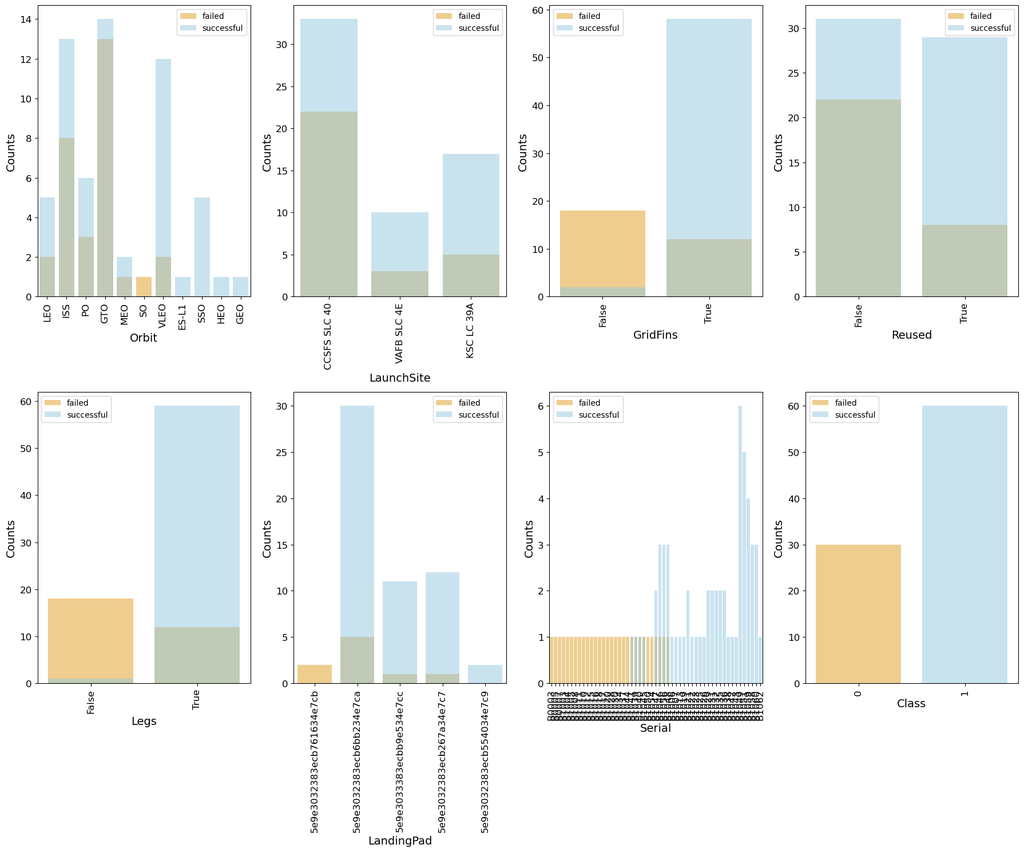

```python
categorical_features = ['Orbit','LaunchSite', 'GridFins', 'Reused','Legs', 'LandingPad','Serial', 'Class']

fig, ax = plt.subplots(2,4 , figsize=(18,15))
ax = ax.flatten()
for i, col in enumerate(categorical_features):

    sns.countplot(
        x=data_falcon9.query('Class == 0')[col],
        ax=ax[i],
        alpha=0.5,
        color='orange', label='failed'
    )

    sns.countplot(
        x=data_falcon9[data_falcon9['Class'] == 1][col],
        ax=ax[i],
        alpha=0.5,
        color='skyblue', label='successful'
        )

    ax[i].set_ylabel("Counts", fontsize=14)
    ax[i].set_xlabel(col, fontsize=14)
    ax[i].tick_params(axis='x', labelsize=12, labelrotation=90)
    ax[i].tick_params(axis='y', labelsize=12)


plt.tight_layout()
plt.legend()
plt.savefig('categorical_features.png')
plt.show()
```

GridFins and Legs show distinguishable patterns for the two cases: Failed and Successful missions. They are likely important features

### converting date to a datetime object, then extracting the year

```python
data_falcon9['Date'] = pd.to_datetime(data_falcon9['Date'])

data_falcon9['Year'] = data_falcon9['Date'].dt.year
```

```python
#data_falcon9.head()
```

### creating density plots for the other features to see if there are patterns reserved only for successful landings and failed landings

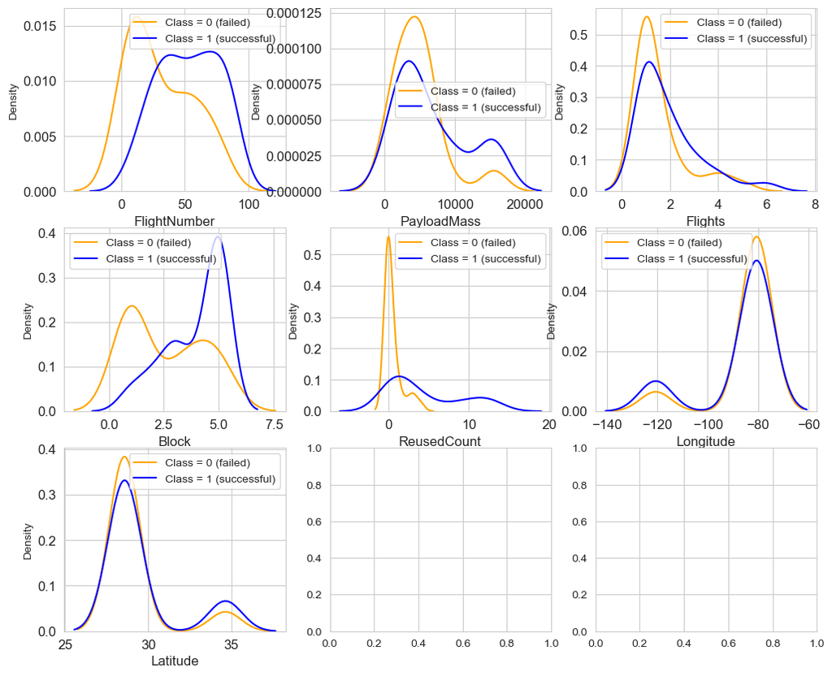

```python
var = data_falcon9.drop(categorical_features+['Date','Year', 'BoosterVersion', 'Outcome', 'Serial'], axis=1).columns

i = 0
t0 = data_falcon9.loc[data_falcon9['Class'] == 0]   # selecting the dataframe where Class = 0
t0 = t0.drop(['Class'], axis=1) # dropping the Class column
t1 = data_falcon9.loc[data_falcon9['Class'] == 1]   # selecting the dataframe where Class = 1
t1 = t1.drop(['Class'], axis=1)

sns.set_style('whitegrid')
plt.figure()
fig, ax = plt.subplots(3,3,figsize=(12,10))

for f in var:
    i += 1
    plt.subplot(3,3,i)
    sns.kdeplot(t0[f],label="Class = 0 (failed)", color='orange')
    sns.kdeplot(t1[f],label="Class = 1 (successful)", color='blue')
    plt.xlabel(f, fontsize=12)
    locs, labels = plt.xticks()
    plt.tick_params(axis='both', which='major', labelsize=12)
    plt.legend()

plt.savefig('feature_density_plots.png')
plt.show()
```

PayLoadMass, Block (upgrades to the booster), ResuedCount show distinguishable features for the two classes. So they are important features in classifying the two classes.

Eventhough FlightNumber also show a distinguishable pattern, it maybe misleading since current mission have been successful so having a higher FlightNumber means it is a more recent launch and has a higher chance of success. Using this feature to train the model would mislead it from learning other important features that actually makes it a successful launch. For example, features like ReusedCount, Legs, Gridfins.

## Feature Enginering

selecting some preliminary features that affect the success rates

dropping FlightNumber and Year

```python
#features = data_falcon9[['FlightNumber', 'PayloadMass', 'Orbit', 'LaunchSite', 'Flights', 'GridFins', 'Reused', 'Legs', 'LandingPad', 'Block', 'ReusedCount', 'Serial','Class', 'Year']]
features = data_falcon9[[ 'PayloadMass', 'Orbit', 'LaunchSite', 'Flights', 'GridFins', 'Reused', 'Legs', 'LandingPad', 'Block', 'ReusedCount', 'Serial','Class']]

features.head()
```

|  | PayloadMass | Orbit | LaunchSite | Flights | GridFins | Reused | Legs | LandingPad | Block | ReusedCount | Serial | Class |
| --- | --- | --- | --- | --- | --- | --- | --- | --- | --- | --- | --- | --- |
| 4 | 6123.547647 | LEO | CCSFS SLC 40 | 1 | False | False | False | None | 1.0 | 0 | B0003 | 0 |
| 5 | 525.000000 | LEO | CCSFS SLC 40 | 1 | False | False | False | None | 1.0 | 0 | B0005 | 0 |
| 6 | 677.000000 | ISS | CCSFS SLC 40 | 1 | False | False | False | None | 1.0 | 0 | B0007 | 0 |
| 7 | 500.000000 | PO | VAFB SLC 4E | 1 | False | False | False | None | 1.0 | 0 | B1003 | 0 |
| 8 | 3170.000000 | GTO | CCSFS SLC 40 | 1 | False | False | False | None | 1.0 | 0 | B1004 | 0 |

```python
data_falcon9['ReusedCount'].unique()
```

```
array([ 0,  1,  3,  2,  4,  9, 12,  5, 13,  8])
```

```python
data_falcon9['Block'].unique()
```

```
array([1., 2., 3., 4., 5.])
```

```python
data_falcon9['Flights'].unique()
```

```
array([1, 2, 3, 4, 5, 6])
```

Use the function `get_dummies` and `features` dataframe to apply OneHotEncoder to the column `Orbits`, `LaunchSite`, `LandingPad`, and `Serial`. Assign the value to the variable `features_one_hot`, display the results using the method head.

```python
features_one_hot = pd.get_dummies(features, columns=['Orbit', 'LaunchSite', 'LandingPad', 'Serial'])

# Display the first 5 rows of the resulting DataFrame
features_one_hot.head()
```

|  | PayloadMass | Flights | GridFins | Reused | Legs | Block | ReusedCount | Class | Orbit_ES-L1 | Orbit_GEO | Orbit_GTO | Orbit_HEO | Orbit_ISS | Orbit_LEO | Orbit_MEO | Orbit_PO | Orbit_SO | Orbit_SSO | Orbit_VLEO | LaunchSite_CCSFS SLC 40 | LaunchSite_KSC LC 39A | LaunchSite_VAFB SLC 4E | LandingPad_5e9e3032383ecb267a34e7c7 | LandingPad_5e9e3032383ecb554034e7c9 | LandingPad_5e9e3032383ecb6bb234e7ca | LandingPad_5e9e3032383ecb761634e7cb | LandingPad_5e9e3033383ecbb9e534e7cc | Serial_B0003 | Serial_B0005 | … |
| --- | --- | --- | --- | --- | --- | --- | --- | --- | --- | --- | --- | --- | --- | --- | --- | --- | --- | --- | --- | --- | --- | --- | --- | --- | --- | --- | --- | --- | --- | --- |
| 4 | 6123.547647 | 1 | False | False | False | 1.0 | 0 | 0 | False | False | False | False | False | True | False | False | False | False | False | True | False | False | False | False | False | False | False | True | False | … |
| 5 | 525.000000 | 1 | False | False | False | 1.0 | 0 | 0 | False | False | False | False | False | True | False | False | False | False | False | True | False | False | False | False | False | False | False | False | True | … |
| 6 | 677.000000 | 1 | False | False | False | 1.0 | 0 | 0 | False | False | False | False | True | False | False | False | False | False | False | True | False | False | False | False | False | False | False | False | False | … |
| 7 | 500.000000 | 1 | False | False | False | 1.0 | 0 | 0 | False | False | False | False | False | False | False | True | False | False | False | False | False | True | False | False | False | False | False | False | False | … |
| 8 | 3170.000000 | 1 | False | False | False | 1.0 | 0 | 0 | False | False | True | False | False | False | False | False | False | False | False | True | False | False | False | False | False | False | False | False | False | … |

```python
features_one_hot = features_one_hot.astype('float64')
```

```python
features_one_hot.head()
```

|  | PayloadMass | Flights | GridFins | Reused | Legs | Block | ReusedCount | Class | Orbit_ES-L1 | Orbit_GEO | Orbit_GTO | Orbit_HEO | Orbit_ISS | Orbit_LEO | Orbit_MEO | Orbit_PO | Orbit_SO | Orbit_SSO | Orbit_VLEO | LaunchSite_CCSFS SLC 40 | LaunchSite_KSC LC 39A | LaunchSite_VAFB SLC 4E | LandingPad_5e9e3032383ecb267a34e7c7 | LandingPad_5e9e3032383ecb554034e7c9 | LandingPad_5e9e3032383ecb6bb234e7ca | LandingPad_5e9e3032383ecb761634e7cb | LandingPad_5e9e3033383ecbb9e534e7cc | Serial_B0003 | Serial_B0005 | … |
| --- | --- | --- | --- | --- | --- | --- | --- | --- | --- | --- | --- | --- | --- | --- | --- | --- | --- | --- | --- | --- | --- | --- | --- | --- | --- | --- | --- | --- | --- | --- |
| 4 | 6123.547647 | 1.0 | 0.0 | 0.0 | 0.0 | 1.0 | 0.0 | 0.0 | 0.0 | 0.0 | 0.0 | 0.0 | 0.0 | 1.0 | 0.0 | 0.0 | 0.0 | 0.0 | 0.0 | 1.0 | 0.0 | 0.0 | 0.0 | 0.0 | 0.0 | 0.0 | 0.0 | 1.0 | 0.0 | … |
| 5 | 525.000000 | 1.0 | 0.0 | 0.0 | 0.0 | 1.0 | 0.0 | 0.0 | 0.0 | 0.0 | 0.0 | 0.0 | 0.0 | 1.0 | 0.0 | 0.0 | 0.0 | 0.0 | 0.0 | 1.0 | 0.0 | 0.0 | 0.0 | 0.0 | 0.0 | 0.0 | 0.0 | 0.0 | 1.0 | … |
| 6 | 677.000000 | 1.0 | 0.0 | 0.0 | 0.0 | 1.0 | 0.0 | 0.0 | 0.0 | 0.0 | 0.0 | 0.0 | 1.0 | 0.0 | 0.0 | 0.0 | 0.0 | 0.0 | 0.0 | 1.0 | 0.0 | 0.0 | 0.0 | 0.0 | 0.0 | 0.0 | 0.0 | 0.0 | 0.0 | … |
| 7 | 500.000000 | 1.0 | 0.0 | 0.0 | 0.0 | 1.0 | 0.0 | 0.0 | 0.0 | 0.0 | 0.0 | 0.0 | 0.0 | 0.0 | 0.0 | 1.0 | 0.0 | 0.0 | 0.0 | 0.0 | 0.0 | 1.0 | 0.0 | 0.0 | 0.0 | 0.0 | 0.0 | 0.0 | 0.0 | … |
| 8 | 3170.000000 | 1.0 | 0.0 | 0.0 | 0.0 | 1.0 | 0.0 | 0.0 | 0.0 | 0.0 | 1.0 | 0.0 | 0.0 | 0.0 | 0.0 | 0.0 | 0.0 | 0.0 | 0.0 | 1.0 | 0.0 | 0.0 | 0.0 | 0.0 | 0.0 | 0.0 | 0.0 | 0.0 | 0.0 | … |

### creating a correlation map

1. To see if certain features are strongly correlated with launch success
2. To check if certain features are highly correlated so we can remove one.

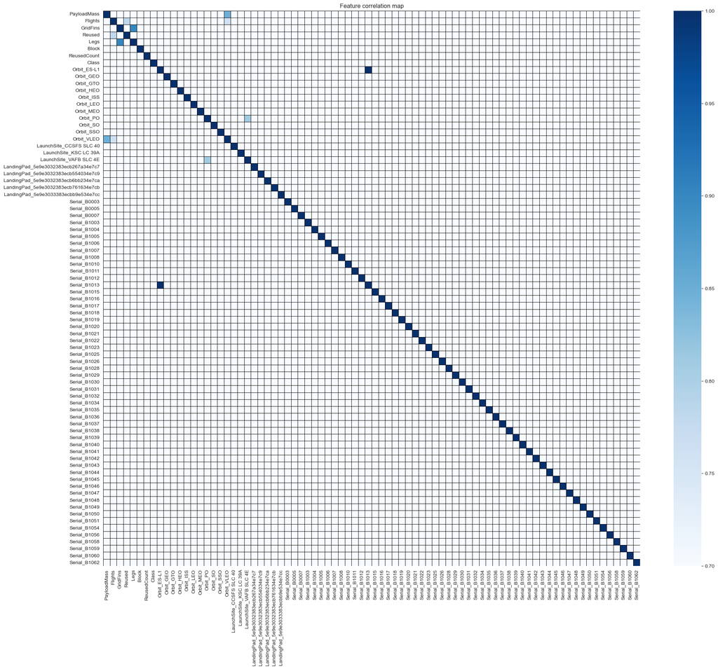

```python
plt.figure(figsize = (24,20))
plt.title('Feature correlation map')

sns.heatmap(features_one_hot.corr(), annot = False, linewidths=0.5, linecolor='black',cmap="Blues", vmin=0.7, vmax=1)

plt.show()
```

```python
features_one_hot.columns
```

```
Index(['PayloadMass', 'Flights', 'GridFins', 'Reused', 'Legs', 'Block',
       'ReusedCount', 'Class', 'Orbit_ES-L1', 'Orbit_GEO', 'Orbit_GTO',
       'Orbit_HEO', 'Orbit_ISS', 'Orbit_LEO', 'Orbit_MEO', 'Orbit_PO',
       'Orbit_SO', 'Orbit_SSO', 'Orbit_VLEO', 'LaunchSite_CCSFS SLC 40',
       'LaunchSite_KSC LC 39A', 'LaunchSite_VAFB SLC 4E',
       'LandingPad_5e9e3032383ecb267a34e7c7',
       'LandingPad_5e9e3032383ecb554034e7c9',
       'LandingPad_5e9e3032383ecb6bb234e7ca',
       'LandingPad_5e9e3032383ecb761634e7cb',
       'LandingPad_5e9e3033383ecbb9e534e7cc', 'Serial_B0003', 'Serial_B0005',
       'Serial_B0007', 'Serial_B1003', 'Serial_B1004', 'Serial_B1005',
       'Serial_B1006', 'Serial_B1007', 'Serial_B1008', 'Serial_B1010',
       'Serial_B1011', 'Serial_B1012', 'Serial_B1013', 'Serial_B1015',
       'Serial_B1016', 'Serial_B1017', 'Serial_B1018', 'Serial_B1019',
       'Serial_B1020', 'Serial_B1021', 'Serial_B1022', 'Serial_B1023',
       'Serial_B1025', 'Serial_B1026', 'Serial_B1028', 'Serial_B1029',
       'Serial_B1030', 'Serial_B1031', 'Serial_B1032', 'Serial_B1034',
       'Serial_B1035', 'Serial_B1036', 'Serial_B1037', 'Serial_B1038',
       'Serial_B1039', 'Serial_B1040', 'Serial_B1041', 'Serial_B1042',
       'Serial_B1043', 'Serial_B1044', 'Serial_B1045', 'Serial_B1046',
       'Serial_B1047', 'Serial_B1048', 'Serial_B1049', 'Serial_B1050',
       'Serial_B1051', 'Serial_B1054', 'Serial_B1056', 'Serial_B1058',
       'Serial_B1059', 'Serial_B1060', 'Serial_B1062'],
      dtype='object')
```

```python
#creating a df without the Class so that it can be used as predictors
features_df =  features_one_hot.drop('Class', axis=1)
```

```python
features_df.columns
```

```
Index(['PayloadMass', 'Flights', 'GridFins', 'Reused', 'Legs', 'Block',
       'ReusedCount', 'Orbit_ES-L1', 'Orbit_GEO', 'Orbit_GTO', 'Orbit_HEO',
       'Orbit_ISS', 'Orbit_LEO', 'Orbit_MEO', 'Orbit_PO', 'Orbit_SO',
       'Orbit_SSO', 'Orbit_VLEO', 'LaunchSite_CCSFS SLC 40',
       'LaunchSite_KSC LC 39A', 'LaunchSite_VAFB SLC 4E',
       'LandingPad_5e9e3032383ecb267a34e7c7',
       'LandingPad_5e9e3032383ecb554034e7c9',
       'LandingPad_5e9e3032383ecb6bb234e7ca',
       'LandingPad_5e9e3032383ecb761634e7cb',
       'LandingPad_5e9e3033383ecbb9e534e7cc', 'Serial_B0003', 'Serial_B0005',
       'Serial_B0007', 'Serial_B1003', 'Serial_B1004', 'Serial_B1005',
       'Serial_B1006', 'Serial_B1007', 'Serial_B1008', 'Serial_B1010',
       'Serial_B1011', 'Serial_B1012', 'Serial_B1013', 'Serial_B1015',
       'Serial_B1016', 'Serial_B1017', 'Serial_B1018', 'Serial_B1019',
       'Serial_B1020', 'Serial_B1021', 'Serial_B1022', 'Serial_B1023',
       'Serial_B1025', 'Serial_B1026', 'Serial_B1028', 'Serial_B1029',
       'Serial_B1030', 'Serial_B1031', 'Serial_B1032', 'Serial_B1034',
       'Serial_B1035', 'Serial_B1036', 'Serial_B1037', 'Serial_B1038',
       'Serial_B1039', 'Serial_B1040', 'Serial_B1041', 'Serial_B1042',
       'Serial_B1043', 'Serial_B1044', 'Serial_B1045', 'Serial_B1046',
       'Serial_B1047', 'Serial_B1048', 'Serial_B1049', 'Serial_B1050',
       'Serial_B1051', 'Serial_B1054', 'Serial_B1056', 'Serial_B1058',
       'Serial_B1059', 'Serial_B1060', 'Serial_B1062'],
      dtype='object')
```

### Predictive Model

importing the necessary libraries

```python
import gc
from datetime import datetime
from sklearn.model_selection import train_test_split
from sklearn.model_selection import KFold
from sklearn.metrics import roc_auc_score, roc_curve
from sklearn.metrics import classification_report, confusion_matrix
from sklearn.ensemble import RandomForestClassifier
from sklearn.ensemble import AdaBoostClassifier
#from catboost import CatBoostClassifier
from sklearn import svm
#import lightgbm as lgb
#from lightgbm import LGBMClassifier
import xgboost as xgb
from xgboost import XGBClassifier
from sklearn.model_selection import StratifiedKFold
```

```python
target = 'Class'
predictors =  list(features_df.columns)
```